# Intro R Answer Key - Week 3

Dr. Dani Kirsch & Dr. Jaina Agan

2026-08-10

## Read in the Dataset

Now that your working directory is set, you should be able to see the dataset we downloaded if you go to the `Files` tab on the lower right of the RStudio interface. If you see a file called `SAFI_clean.csv`, everything is in order.

Import the dataset using the `read_csv()` function since it is a CSV file. Don’t forget to put the file name in `" "` and include the file extension `.csv`. Store the dataset as an object called `survey_data` so that we can reference it in the next section.

```r
survey_data <- read_csv("SAFI_clean.csv")
```

## Practice Problems

### Working with Data

In this section, you will be writing code to subset, transform, and create new variables from our `survey_data` dataset we imported.

1. **Subset the original dataset so that it includes the following components and store it as an object called `bigger_households`:**
   - Only the columns `village`, `no_membrs`, `respondent_wall_type`, and `rooms`
   - Only households that have at least 8 people living in them (`no_membrs`)

Your subset should look something like this:

```r
bigger_households <- survey_data %>%
  filter(no_membrs >= 8) %>%
  select(village, no_membrs, respondent_wall_type, rooms)

bigger_households
```

```
## # A tibble: 49 × 4
##    village  no_membrs respondent_wall_type rooms
##    <chr>        <dbl> <chr>                <dbl>
##  1 God             10 burntbricks              1
##  2 Chirodzo        12 burntbricks              3
##  3 Chirodzo         8 burntbricks              1
##  4 Chirodzo        12 burntbricks              5
##  5 God             10 burntbricks              3
##  6 God              8 sunbricks                1
##  7 God              9 burntbricks              2
##  8 God              8 burntbricks              1
##  9 Ruaca           10 burntbricks              4
## 10 Ruaca           11 burntbricks              3
## # ℹ 39 more rows
```

2. **Subset the original dataset so that it includes the following components and store it as an object called `earth_households`:**
   - Only households where `respondent_wall_type` is either “muddaub”, “burntbricks”, and “sunbricks”
   - Contains a new column called `membrs_per_room` that contains a calculation of the number of household members per room (`no_membrs / rooms`)
   - Contains a new column called `wall_as_factor` that contains the same data as `respondent_wall_type` but converted into a factor instead
   - Change the order of factor levels to “sunbricks”, “burntbricks” and “muddaub” (**Hint**: use `fct_relevel()`)
   - Select only the variables `no_membrs`, `rooms`, `membrs_per_room`, and `wall_as_factor`

Your subset should look something like this:

```r
earth_households <- survey_data %>%
  filter(respondent_wall_type %in% c("muddaub","burntbricks","sunbricks")) %>%
  mutate(membrs_per_room = no_membrs / rooms,
         wall_as_factor = factor(respondent_wall_type),
         wall_as_factor = fct_relevel(wall_as_factor,
                                      c("sunbricks",
                                        "burntbricks",
                                        "muddaub"))) %>%
  select(no_membrs, rooms, membrs_per_room, wall_as_factor)

earth_households
```

```
## # A tibble: 130 × 4
##    no_membrs rooms membrs_per_room wall_as_factor
##        <dbl> <dbl>           <dbl> <fct>
##  1         3     1             3   muddaub
##  2         7     1             7   muddaub
##  3        10     1            10   burntbricks
##  4         7     1             7   burntbricks
##  5         7     1             7   burntbricks
##  6         3     1             3   muddaub
##  7         6     1             6   muddaub
##  8        12     3             4   burntbricks
##  9         8     1             8   burntbricks
## 10        12     5             2.4 burntbricks
## # ℹ 120 more rows
```

3. **Use the `group_by()` and `summarize()` approach to make the following comparisons between villages (`village`) from the original dataset (`survey_data`):**
   - Average years lived in the area (`years_liv`)
   - Number of households in each village (**Hint**: use `n()`)

Your comparison table should look like this:

```r
survey_data %>%
  group_by(village) %>%
  summarize(mean_years_liv = mean(years_liv),
            n = n())
```

```
## # A tibble: 3 × 3
##   village  mean_years_liv     n
##   <chr>             <dbl> <int>
## 1 Chirodzo           23.6    39
## 2 God                20.4    43
## 3 Ruaca              24.9    49
```

### Putting It All Together

1. **Create a subset that includes the following components and store it as an object called `survey_50_years`:**
   - Use `str` to verify that `interview_date` is a **date** data type
   - Create a new variable called `year` by extracting the year from `interview_date`. (**Hint**: the function `year()` can extract the year from a date)
   - Convert `year` to a factor
   - Filter so that only households that have been living in the area for less than 50 years are represented

Your subset should look something like this:

- **Note**: `<dttm>` is shorthand for “date-time” and is a specific type of date data type

```r
str(survey_data$interview_date)
```

```
##  POSIXct[1:131], format: "2016-11-17" "2016-11-17" "2016-11-17" "2016-11-17" "2016-11-17" ...
```

```r
survey_50_years <- survey_data %>%
  mutate(year = year(interview_date),
         year = factor(year)) %>%
  filter(years_liv < 50)

survey_50_years
```

```
## # A tibble: 122 × 15
##    key_ID village  interview_date      no_membrs years_liv respondent_wall_type
##     <dbl> <chr>    <dttm>                  <dbl>     <dbl> <chr>
##  1      1 God      2016-11-17 00:00:00         3         4 muddaub
##  2      2 God      2016-11-17 00:00:00         7         9 muddaub
##  3      3 God      2016-11-17 00:00:00        10        15 burntbricks
##  4      4 God      2016-11-17 00:00:00         7         6 burntbricks
##  5      5 God      2016-11-17 00:00:00         7        40 burntbricks
##  6      6 God      2016-11-17 00:00:00         3         3 muddaub
##  7      7 God      2016-11-17 00:00:00         6        38 muddaub
##  8      9 Chirodzo 2016-11-16 00:00:00         8         6 burntbricks
##  9     10 Chirodzo 2016-12-16 00:00:00        12        23 burntbricks
## 10     11 God      2016-11-21 00:00:00         6        20 sunbricks
## # ℹ 112 more rows
## # ℹ 9 more variables: rooms <dbl>, memb_assoc <chr>, affect_conflicts <chr>,
## #   liv_count <dbl>, items_owned <chr>, no_meals <dbl>, months_lack_food <chr>,
## #   instanceID <chr>, year <fct>
```

2. **Create a data visualization using the `survey_50_years` subset that has the following features:**
   - `year` (as a factor) on the x-axis and `no_membrs` on the y-axis
   - create a boxplot and remove the outlier points
   - create a `geom_jitter` layer to plot the raw data points and specify that
     - color should vary by `village` (but **only** for the jitter layer)
     - change the transparency to 0.7
     - change the point size to 2 (`size =`)
   - Add your own additional customizations. For example:
     - change the axis titles
     - change the color of the data points
     - change the graph theme
     - change the font size
   - Store this graph as an object called `years_graph`

Your exact customizations will vary, but the graph generally should look like the following:

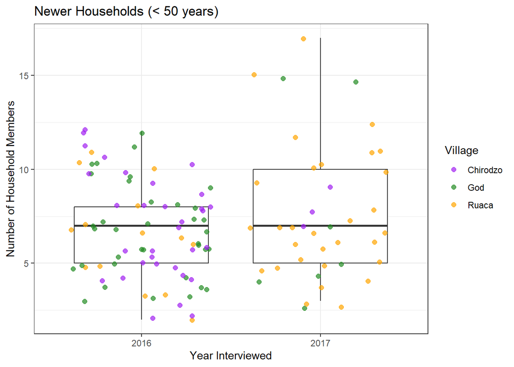

```r
years_graph <- ggplot(data = survey_50_years,
       mapping = aes(x = year,
                     y = no_membrs)) +
  geom_boxplot(outlier.shape = NA) +
  geom_jitter(aes(color = village),
              alpha = 0.7,
              size = 2) +
  theme_bw() +
  labs(x = "Year Interviewed",
       y = "Number of Household Members",
       color = "Village",
       title = "Newer Households (< 50 years)") +
  scale_color_manual(values = c("purple","forestgreen","orange"))

years_graph # print the graph in the Plots pane
```

3. **Export the subset `survey_50_years` and the graph you just made.**
   - The functions `ggsave` and `write_csv` will be useful here.
   - **Please attach these exported files with the rest of your microcredential submission!**

```r
ggsave(filename = "years_graph.png",
       plot = years_graph,
       width = 6,
       height = 4,
       dpi = 300)

write_csv(survey_50_years,
          file = "new_house_survey_data.csv")
```

## Reflections

1. What was the most challenging aspect of this week’s workshop? Were you able to overcome it? If not, what assistance do you need to continue working through it?
2. What was the most rewarding aspect of this week’s workshop?
3. What are you most excited to try next in R?